# AppFigure Report

George Li

2/16/2019

### PART I

The SSIS data flow packaged is created for loading csv to SQL Server. Data types are strings which further modification could be added.

##### Step 0: specify directories.

```r
set.seed(2018)
setwd("~/Documents/GitHub/AppFigures")
# use relative path for reproducibility
```

###### Step 1: EDA

Initially mapping with sales_tbl id with ranks_tbl id. A summry of 599 observations labeled data without NA, and 96503 observations to be predicted with NA. A scatter plot shows the inverse relationship between app ranking and sales. A histogram shows the distribution of app_id with sales label shows great variance and unbalanced app frequencies while collecting from source.

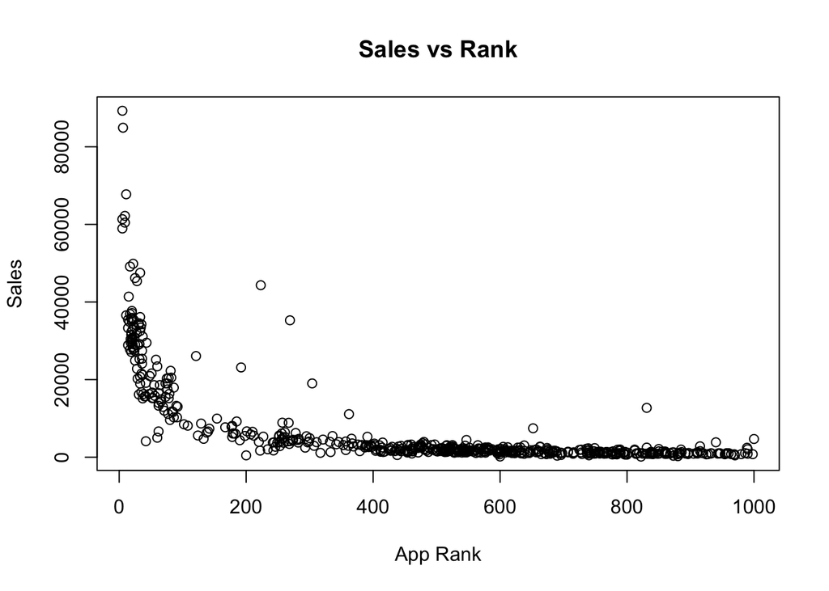

```r
plot(x = dt_label$r0, y = dt_label$sales, xlab = "App Rank", ylab = "Sales", main = "Sales vs Rank")
```

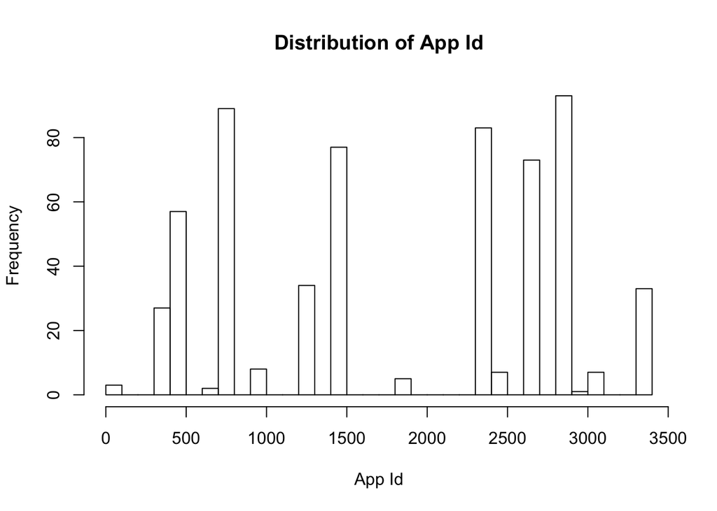

```r
hist(dt_label$app_id, breaks = id_length, xlab = "App Id", ylab = "Frequency", main = "Distribution of App Id")
```

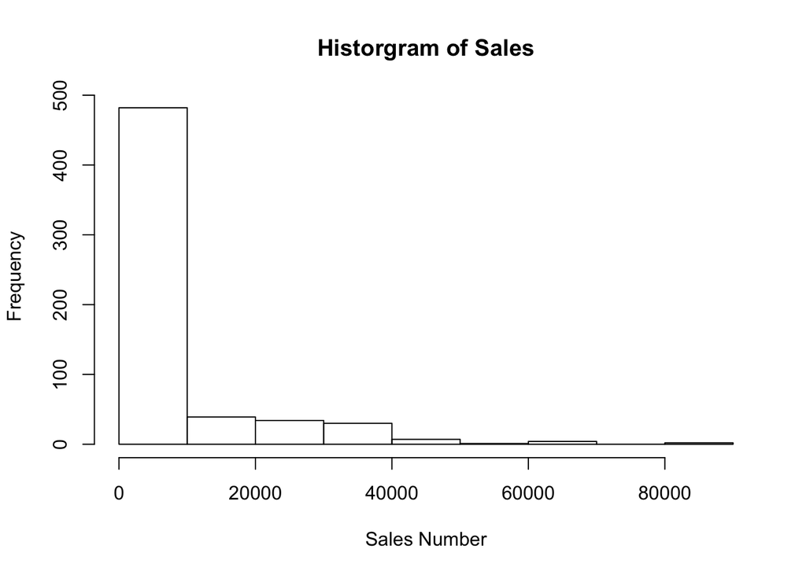

```r
hist(dt_label$sales, xlab = "Sales Number", main = "Historgram of Sales")
```

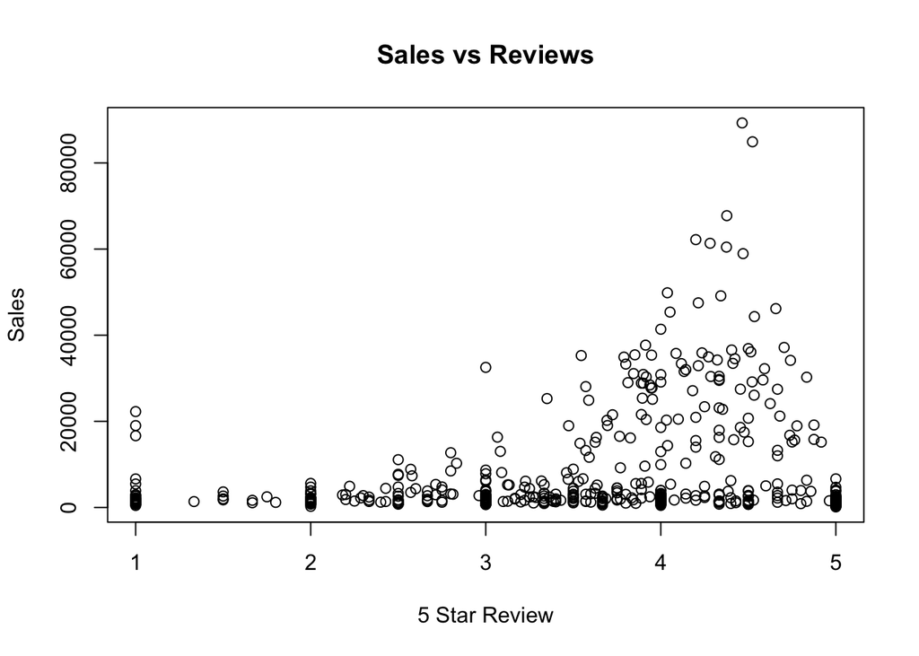

```r
plot(x = dt_label$s_mean, y = dt_label$sales, xlab = "5 Star Review", ylab = "Sales", main = "Sales vs Reviews")
```

```r
summary(dt_app)
```

```
##      app_id           r_avg            s_avg           sales
##  Min.   :  82.0   Min.   : 35.36   Min.   :1.400   Min.   :  151.0
##  1st Qu.: 988.8   1st Qu.:507.67   1st Qu.:3.000   1st Qu.:  960.4
##  Median :2103.5   Median :634.59   Median :3.517   Median : 1567.2
##  Mean   :1875.0   Mean   :598.02   Mean   :3.538   Mean   : 3671.8
##  3rd Qu.:2782.5   3rd Qu.:787.96   3rd Qu.:4.249   3rd Qu.: 2688.3
##  Max.   :3373.0   Max.   :927.38   Max.   :5.000   Max.   :29437.5
```

```r
cor.test(dt_app$r_avg, dt_app$sales, method=c("pearson", "kendall", "spearman"))
```

```
##
##  Pearson's product-moment correlation
##
## data:  dt_app$r_avg and dt_app$sales
## t = -6.109, df = 24, p-value = 2.608e-06
## alternative hypothesis: true correlation is not equal to 0
## 95 percent confidence interval:
##  -0.8965583 -0.5628755
## sample estimates:
##        cor
## -0.7801341
```

```r
cor.test(dt_app$s_avg, dt_app$sales, method=c("pearson", "kendall", "spearman"))
```

```
##
##  Pearson's product-moment correlation
##
## data:  dt_app$s_avg and dt_app$sales
## t = 0.010006, df = 24, p-value = 0.9921
## alternative hypothesis: true correlation is not equal to 0
## 95 percent confidence interval:
##  -0.3856145  0.3890866
## sample estimates:
##         cor
## 0.002042506
```

```r
cor.test(dt_app$r_avg, dt_app$s_avg, method=c("pearson", "kendall", "spearman"))
```

```
##
##  Pearson's product-moment correlation
##
## data:  dt_app$r_avg and dt_app$s_avg
## t = 0.23727, df = 24, p-value = 0.8145
## alternative hypothesis: true correlation is not equal to 0
## 95 percent confidence interval:
##  -0.3454489  0.4277135
## sample estimates:
##       cor
## 0.0483763
```

Outliers are easily detected with large deviation from the mean by using cooks distance. Outliers could be normal phenomenon with some popular apps so further dealing with these points should discuss with manager (here the data is kept).

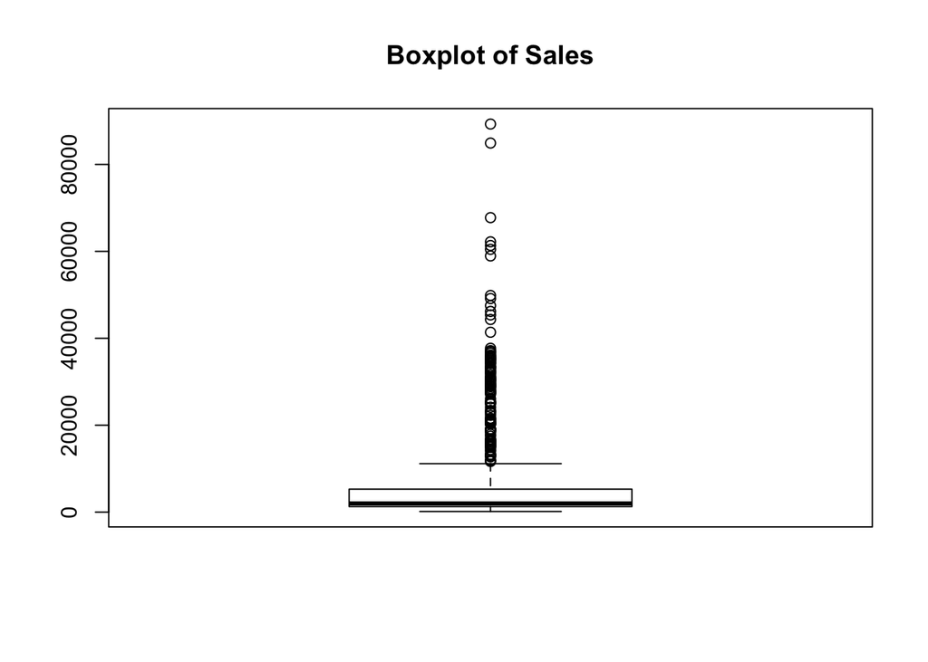

```r
boxplot(dt_label$sales, main = "Boxplot of Sales")
```

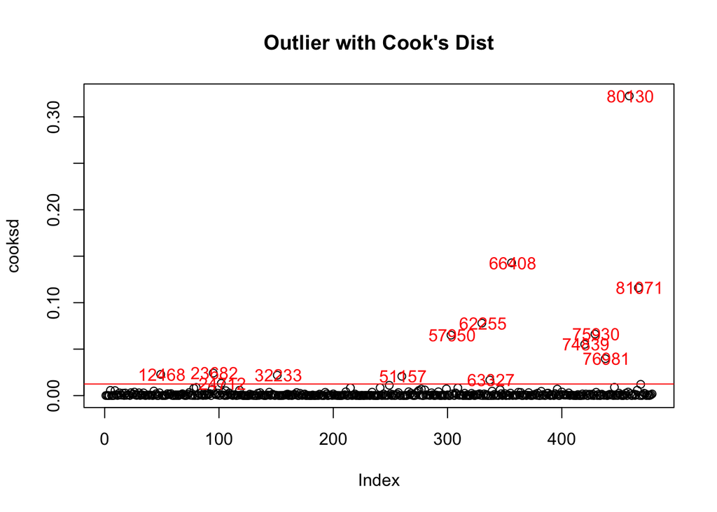

```r
plot(cooksd, main = "Outlier with Cook's Dist")
abline(h = 4*mean(cooksd, na.rm=T), col="red")  # add cutoff line
text(x=1:length(cooksd)+1, y=cooksd, labels=ifelse(cooksd>4*mean(cooksd, na.rm=T),names(cooksd),""), col="red")  # add labels
```

Note: PCA is not used for this dataset. r0 - r23 does not provide additional information which is representitve by r0. s1 - s5 could be summerized by the arithmetic mean. Thus, only two variables makes contribution to sales number.

##### Step 2: Model w/ prediction

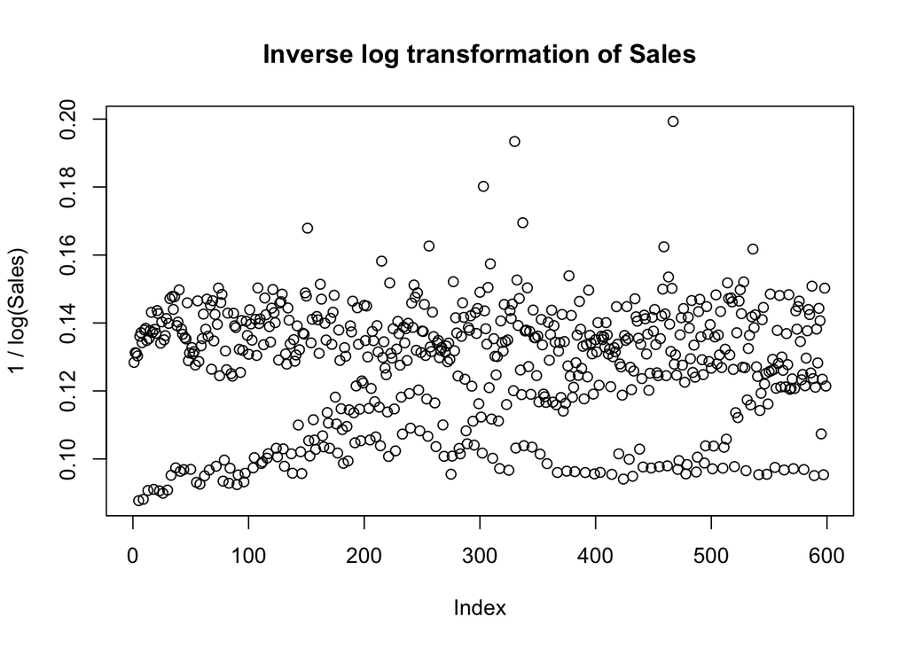

```r
plot(1/log(dt_label$sales), ylab = "1 / log(Sales)", main = "Inverse log transformation of Sales")
```

```r
summary(model_linear)
```

```
##
## Call:
## glm(formula = 1/log(sales) ~ r0 + s_mean + r0 * s_mean, family = "gaussian",
##     data = train)
##
## Deviance Residuals:
##       Min         1Q     Median         3Q        Max
## -0.041676  -0.004214  -0.000429   0.003271   0.058846
##
## Coefficients:
##               Estimate Std. Error t value Pr(>|t|)
## (Intercept)  1.161e-01  3.262e-03  35.573  < 2e-16 ***
## r0           3.140e-05  5.190e-06   6.051 2.92e-09 ***
## s_mean      -3.922e-03  8.352e-04  -4.696 3.48e-06 ***
## r0:s_mean    6.425e-06  1.333e-06   4.822 1.92e-06 ***
## ---
## Signif. codes:  0 '***' 0.001 '**' 0.01 '*' 0.05 '.' 0.1 ' ' 1
##
## (Dispersion parameter for gaussian family taken to be 6.904231e-05)
##
##     Null deviance: 0.153266  on 478  degrees of freedom
## Residual deviance: 0.032795  on 475  degrees of freedom
## AIC: -3223.9
##
## Number of Fisher Scoring iterations: 2
```

### Part II

Originally the model is intended to use time series model. In a general perspective, we could inspect that today’s sales could be largely correlated with yesterday’s download number. Indeed for dt_label, there is lag relationship between time and sales. However, in app-specific level, the seasonality vary greatly within different apps and ARMA model would yield differet coefficients. Therefore, a ARMA / GARCH model would be encouraged but a longer time longevity is definitely needed.

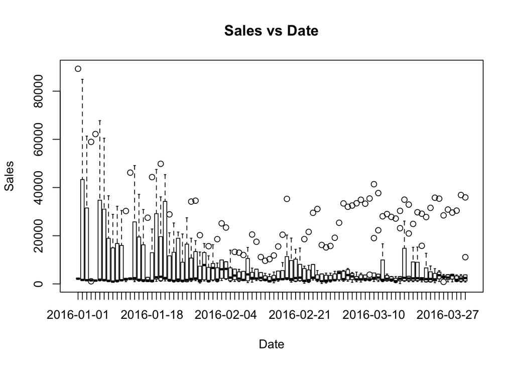

```r
plot(x = dt_label$Date, y = dt_label$sales, xlab = "Date", ylab = "Sales", main = "Sales vs Date")
```

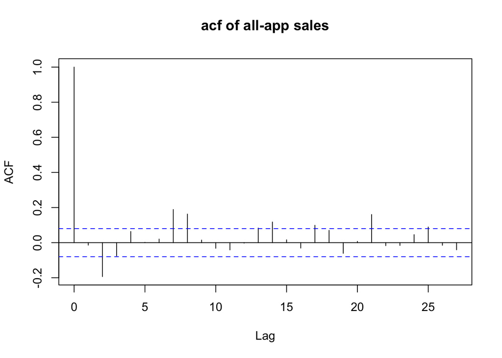

```r
acf(dt_label$sales, main = "acf of all-app sales")
```

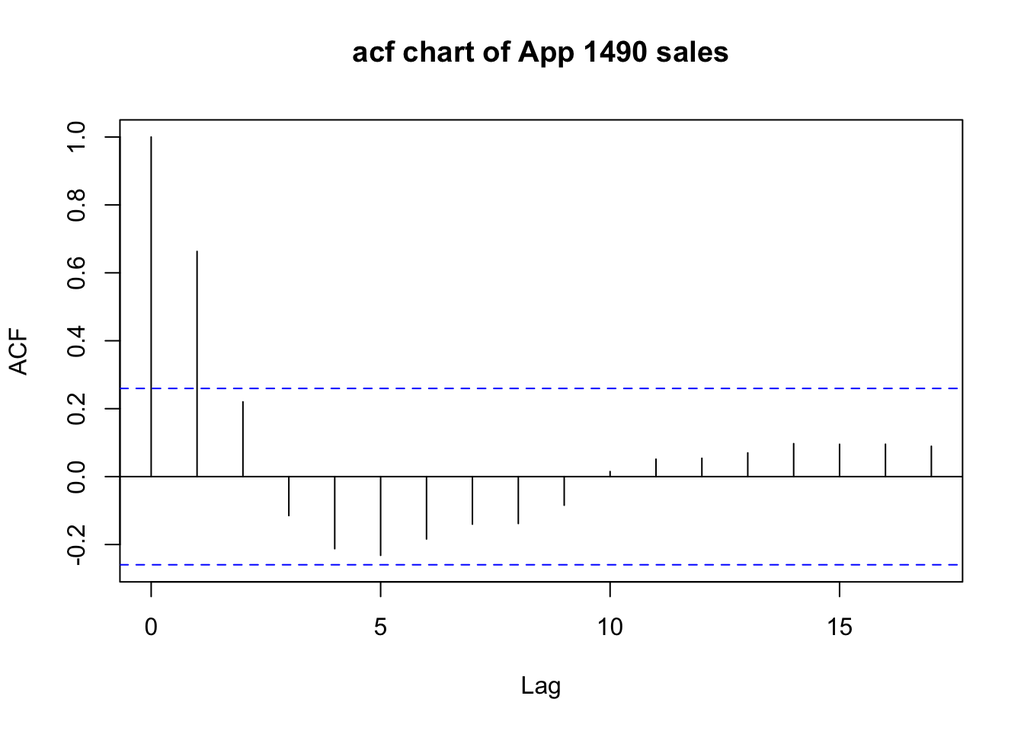

```r
acf(dt_label[dt_label$app_id==1490,]$sales, main = "acf chart of App 1490 sales")
```